# 20172_M2.855_PEC4_Solucion

[figure not shown]

M2.855 · Modelos avanzados de minería de datos · PEC4

2017-2 · Máster universitario en Ciencia de datos (Data science)

Estudios de Informática, Multimedia y Telecomunicación

# PEC 4: Combinación de clasificadores

En esta práctica veremos diferentes métodos de combinación de clasificadores aplicados sobre el conjunto de datos [EMNIST](https://www.nist.gov/itl/iad/image-group/emnist-dataset).

0. Carga de datos
1. Combinación paralela de clasificadores base similares  
   1.1 Bagging  
   . 1.1.1 Random Forest simple  
   . 1.1.2 Out-of-bag  
   . 1.1.3 Probabilidad por clase  
   . 1.1.4 Importancia de las variables  
   . 1.1.5 Número de clasificadores  
   . 1.1.6 Volumen de datos  
   1.2 Boosting
2. Combinación secuencial de clasificadores base diferentes  
   2.1 Stacking  
   2.2 Cascading  
   . 2.2.1 Cascading simple  
   . 2.2.2 Cascading con variables adicionales

**Importante: Cada uno de los ejercicios puede suponer varios minutos de ejecución, por lo que la entrega debe hacerse en formato notebook y en formato html donde se vea el código y los resultados y comentarios de cada ejercicio. Para exportar el notebook a html puede hacerse desde el menú File $\to$ Download as $\to$ HTML.**

# 0. Carga de datos

Usaremos los mismos datos que en la práctica anterior, PEC 3, que son las 5.000 imágenes EMMNIST, correspondientes a 5 carácteres distintos: "A", "B", "C", "D" y "E.

El siguiente código cargará las imágenes:

```python
import pickle
import numpy as np

with open("data.pickle", "rb") as f:
    data = pickle.load(f)

images = data["images"]
labels = data["labels"]
n_classes = 5
labels_text = ["A", "B", "C", "D", "E"]

print("Dimensiones del vector de imágenes: {}".format(images.shape))
print("Dimensiones del vector de etiquetas: {}".format(labels.shape))
```

```
Dimensiones del vector de imágenes: (5000, 784)
Dimensiones del vector de etiquetas: (5000,)
```

Con el siguiente código podemos ver un ejemplo de imagen de cada una de las clases. Para ello reajustamos el vector de 784 dimensiones que representa cada imagen en una matriz de tamaño 28x28 y la transponemos para mostrarla:

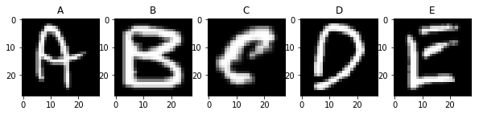

```python
import matplotlib.pyplot as plt
%matplotlib inline

fig, ax = plt.subplots(1, n_classes, figsize=(10,10))

idxs = [np.where(labels == i)[0] for i in range(n_classes)]

for i in range(n_classes):
    k = np.random.choice(idxs[i])
    ax[i].imshow(images[k].reshape(28, 28).transpose(), cmap="gray")
    ax[i].set_title("{}".format(labels_text[i]))
```

Reducimos dimensionalidad usando PCA y dividimos los datos, tal como en el PEC3, en 4000 imágenes entrenamiento y 1000 imágenes para test.

```python
from sklearn.model_selection import train_test_split
from sklearn.decomposition import PCA

X_train, X_test, y_train, y_test = train_test_split(images, labels, test_size=0.2, random_state=2017, stratify=labels)

pca = PCA(n_components=100, random_state=2017)
pca_fit = pca.fit(X_train)
X_train_pca = pca_fit.transform(X_train)
X_test_pca = pca_fit.transform(X_test)

def proporcion_etiquetas(y):
    _, count = np.unique(y, return_counts=True)
    return np.true_divide(count, y.shape[0])


print("Número de imágenes para entrenar: {}".format(X_train_pca.shape[0]))
print("Número de imágenes para test: {}".format(X_test_pca.shape[0]))

print("Proporción de las etiquetas en el conjunto original: {}".format(proporcion_etiquetas(labels)))
print("Proporción de las etiquetas en el conjunto de entrenamiento: {}".format(proporcion_etiquetas(y_train)))
print("Proporción de las etiquetas en el conjunto de test: {}".format(proporcion_etiquetas(y_test)))
```

```
Número de imágenes para entrenar: 4000
Número de imágenes para test: 1000
Proporción de las etiquetas en el conjunto original: [0.2 0.2 0.2 0.2 0.2]
Proporción de las etiquetas en el conjunto de entrenamiento: [0.2 0.2 0.2 0.2 0.2]
Proporción de las etiquetas en el conjunto de test: [0.2 0.2 0.2 0.2 0.2]
```

# 1. Combinación paralela de clasificadores base similares

## 1.1 Bagging

### 1.1.1 Random forest simple (1 punto)

La idea básica del *bagging* es utilizar el conjunto de entrenamiento original para generar centenares o miles de conjuntos similares usando muestreo con reemplazo. En este concepto está basado el algoritmo *Random Forest*, la combinación de varios árboles de decisión, cada uno entrenado con una realización diferente de los datos. La decisión final del clasificador combinado (la *Random Forest*) se toma por mayoría, dando el mismo peso a todas las decisiones parciales tomadas por los clasificadores base (los árboles).

**Implementación:** Usando los conjuntos *X_train_pca* e *y_train_pca*, entrenar un modelo *Random Forest* con 100 árboles de decisión y estimar la precisión del modelo con una estrategia de *cross-validation* en los mismos conjuntos.

Sugerencia: usar los módulos *RandomForestClassifier* y *cross_val_score* de sklearn. Para aprender más sobre *cross validation* y sobre como usar estes módulos, os recomendamos los siguientes enlaces:  
http://scikit-learn.org/stable/modules/generated/sklearn.ensemble.RandomForestClassifier.html  
http://scikit-learn.org/stable/modules/cross_validation.html  
http://scikit-learn.org/stable/modules/generated/sklearn.model_selection.cross_val_score.html

**Solución:**

```python
#############################################
# SOLUCION                                  #
#############################################

from sklearn import ensemble
from sklearn.model_selection import cross_val_score
from time import time

clf = ensemble.RandomForestClassifier(n_estimators=100)

cvscores = cross_val_score(clf, X_train_pca, y_train, cv=5)

print("Precisión media obtenida con CV: {:.2f} +/- {:.2f} %".format(np.mean(cvscores)*100, np.std(cvscores)*100))
```

```
Precisión media obtenida con CV: 92.30 +/- 0.57 %
```

### 1.1.2 Out-of-bag (1 punto)

Una ventaja del *bagging* usado en el *Random Forest* es que cada uno de los árboles de decisión ha sido entrenado con una combinación diferente de los datos (muestreo con reemplazo), o sea que cada uno de los árboles no ha visto una determinada parte de los datos originales. Esto define una especie de conjunto de test para cada uno de los árboles, llamado *out-of-bag*, que puede ser usado para estimar el error del modelo sin necesidad de usar el conjunto de test real que creamos previamente, ni de usar estrategias de *cross-validation*.

**Implementación:** Usando los conjuntos *X_train_pca* e *y_train_pca*, entrenar un modelo Random Forest con 100 árboles de decisión. Mostrar la precisión de este modelo en el *out-of-bag* y en el conjunto *X_test_pca*.

Sugerencia: usar el módulo *RandomForestClassifier* de sklearn. Para aprender más sobre *out-of-bag* y sobre como usar este módulo (incluyendo el atributo *oob_score_*), os recomendamos los siguientes enlaces:  
http://scikit-learn.org/stable/modules/generated/sklearn.ensemble.RandomForestClassifier.html  
http://scikit-learn.org/stable/auto_examples/ensemble/plot_ensemble_oob.html

**Solución:**

```python
#############################################
# SOLUCION                                  #
#############################################

from sklearn import ensemble

clf = ensemble.RandomForestClassifier(n_estimators=100, oob_score=True, random_state=2017)

clf.fit(X_train_pca, y_train)

print("Precisión Out-of-bag: {:.2f} %".format(clf.oob_score_*100))

preds_rfc = clf.predict(X_test_pca)
accuracy = np.true_divide(np.sum(preds_rfc == y_test), preds_rfc.shape[0])*100
print("Precisión en el conjunto de test: {:.2f}%".format(accuracy))
```

```
Precisión Out-of-bag: 90.55 %
Precisión en el conjunto de test: 92.80%
```

**Análisis:** La precisión obtenida en el *out-of-bag* y en el conjunto de test son comparables? Era de esperar?

**Solución:**  
- La precisión medida en el out-of-bag y la obtenida en el conjunto de test son parecidas.  
- Este resultado era de esperar porque: por un lado, la estimación del error con el out-of-bag es un método robusto y nos dá el error del modelo en el conjunto de datos X_train_pca; por el otro lado, el error en el conjunto de datos de test X_test_pca es muy parecido porque X_test_pca tiene la misma estructura (fue creado con separación aleatoria estratificada) que el conjunto de datos de entrenamiento X_train_pca.  
- BONUS: Era también de esperar que el error OOB fuese ligeramente mayor (precisión menor), ver:  
https://www.salford-systems.com/blog/dan-steinberg/random-forests-oob-vs-test-partition-performance https://www.stat.berkeley.edu/~breiman/OOBestimation.pdf

### 1.1.3 Probabilidad por clase (1 punto)

Otra ventaja del *bagging* usado en el *Random Forest* es que cada uno de los árboles de decisión, entrenado con una combinación diferente de los datos, puede obtener un resultado diferente. En los problemas de clasificación, el resultado de cada árbol se considera como un voto diferente, y la predicción final del modelo es la clase que haya obtenido más votos teniendo en cuenta todos los árboles.

Estos votos individuales de los árboles también se pueden usar para estimar la probabilidad con la que el modelo prevé cada una de las clases, siendo la probabilidad para cada clase igual al número de votos obtenidos para aquella clase dividido entre el número de árboles.

**Implementación:** Para cada clase (etiqueta), muestra un ejemplo de imágen que el modelo haya clasificado incorrectamente junto con la etiqueta asignada por el modelo y la etiqueta original. Muestra también las probabilidades que el modelo ha atribuído a cada clase para estas imágenes.

Sugerencia: usa el modelo que entrenaste en el ejercicio anterior con el módulo *RandomForestClassifier* de sklearn y las previsiones que calculaste para el conjunto de datos de test. Para mostrar las imágenes, usa el código proporcionado en la sección 0. Para aprender más sobre el módulo *RandomForestClassifier* de sklearn (incluyendo el método *predict_proba*), os recomendamos el siguiente enlace:  
http://scikit-learn.org/stable/modules/generated/sklearn.ensemble.RandomForestClassifier.html

**Solución:**

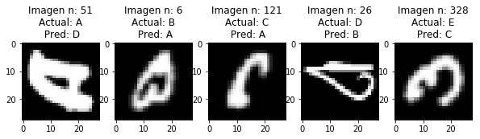

```python
#############################################
# SOLUCION                                  #
#############################################

import matplotlib.pyplot as plt
%matplotlib inline

# Obtener los índices de la primera imagen mal identificada para cada clase:
idxs = [np.where((y_test == i) & (preds_rfc != i))[0][0] for i in range(n_classes)]

# Mostrar las imágenes junto con las etiquetas actuales y previstas:
fig, ax = plt.subplots(1, n_classes, figsize=(10,10))
for i in range(n_classes):
    k = idxs[i]
    ax[i].imshow(X_test[k].reshape(28, 28), cmap="gray")
    ax[i].set_title("Imagen n: {}\nActual: {}\n Pred: {}".format(k, labels_text[y_test[k]], labels_text[preds_rfc[k]]))
```

```python
#############################################
# SOLUCION                                  #
#############################################

# Calcular las probabilidades de cada clase para cada imagen:
probs_rfc = clf.predict_proba(X_test_pca)

# Mostrar las probabilidades junto con la clase prevista (probabilidad més alta) y la real
print("Etiquetas: \t\t\t{}".format(labels_text))
for i in range(n_classes):
    k = idxs[i]
    print("Probabilidades imagen {}:\t{}; Actual: '{}'; Pred: '{}'".format(k, probs_rfc[k], labels_text[y_test[k]], labels_text[preds_rfc[k]]))

# Adicional: calcular cuantas veces la segunda clase con más probabilidad era la correcta:
n_max_prob_correct = 0
n_2nd_max_prob_correct = 0
for i in range(len(y_test)):
    if y_test[i] == np.argmax(probs_rfc[i]):
        n_max_prob_correct += 1
    elif y_test[i] == probs_rfc[i].argsort()[-2]:
        n_2nd_max_prob_correct += 1
print("\nCuantas veces el modelo acertó? (precisión): {}%\nDe las veces que no acertó, cuantas veces la segunda clase más votada era la correcta?: {:.1f}%" \
      .format(float(n_max_prob_correct)/len(y_test)*100,
              float(n_2nd_max_prob_correct)/(len(y_test)-n_max_prob_correct)*100))
```

```
Etiquetas: 			['A', 'B', 'C', 'D', 'E']
Probabilidades imagen 51:	[0.21 0.16 0.06 0.43 0.14]; Actual: 'A'; Pred: 'D'
Probabilidades imagen 6:	[0.37 0.14 0.09 0.14 0.26]; Actual: 'B'; Pred: 'A'
Probabilidades imagen 121:	[0.49 0.14 0.08 0.15 0.14]; Actual: 'C'; Pred: 'A'
Probabilidades imagen 26:	[0.19 0.27 0.12 0.24 0.18]; Actual: 'D'; Pred: 'B'
Probabilidades imagen 328:	[0.06 0.1  0.4  0.08 0.36]; Actual: 'E'; Pred: 'C'

Cuantas veces el modelo acertó? (precisión): 92.80000000000001%
De las veces que no acertó, cuantas veces la segunda clase más votada era la correcta?: 69.4%
```

**Análisis:** En estos casos en los que el modelo se equivocó, estaba cerca de prever la etiqueta correcta?

### 1.1.4 Importancia de las variables (1 punto)

Otra ventaja del algoritmo *Random Forest* es que permite medir la importancia relativa de cada variable, gracias a que cada uno de los árboles fué entrenado con un subconjunto diferente de las variables originales.

En el problema de clasificación de imágenes analizado aquí, la importancia de las variables nos permite saber cuáles son generalmente los píxeles más importantes par poder clasificar la imágen.

**Implementación:** Entrena un clasificador *Random Forest* con el conjunto de datos de entrenamiento original *X_train*, en los que cada variable es la intensidad de cada píxel (en vez de ser las variables PCA que usamos anteriormente). Muestra cuáles son las 10 variables más importantes. Haz un gráfico en el que se vea que zonas de una imágen son más importantes para el clasificador.

Sugerencia: usa el módulo *RandomForestClassifier* de sklearn para calcular la importancia de las variables. Para representar gráficamente la importancia de cada píxel de la imagen, usa parte del código proporcionado en la sección 0. Para aprender más sobre el módulo *RandomForestClassifier* de sklearn (incluyendo el método *feature_importances_*), os recomendamos el siguiente enlace:  
http://scikit-learn.org/stable/modules/generated/sklearn.ensemble.RandomForestClassifier.html

**Solución:**

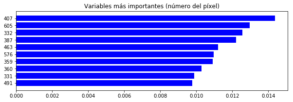

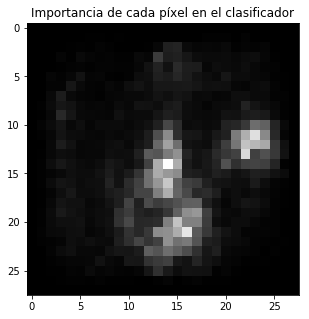

```python
#############################################
# SOLUCION                                  #
#############################################

# entrenar clasificador con datos originales, sin PCA, para que cada variable sea la intensidad de cada píxel:
clf = ensemble.RandomForestClassifier(n_estimators=80)
clf.fit(X_train, y_train)

# cálculo de la importancia de las variables y representación gráfica de las top 10:
importances = clf.feature_importances_
topN = 10
indices = np.argsort(importances)
n_feats = min(len(importances), topN)
labels = np.arange(1, np.shape(X_train)[1]+1) # nombres de las variables, en este caso número del píxel
plt.figure(figsize=(10,3))
plt.title("Variables más importantes (número del píxel)")
plt.barh(range(n_feats), importances[indices][-n_feats:], color="b")
plt.yticks(range(n_feats), labels[indices][-n_feats:])
plt.ylim([-1, n_feats])
plt.show()

# representación gráfica de la importancia de cada píxel:
plt.figure(figsize=(5,5))
plt.title("Importancia de cada píxel en el clasificador")
plt.imshow(importances.reshape(28, 28), cmap="gray")
plt.show()
```

**Análisis:** Te parece plausible el resultado que has obtenido? Porqué?

**Solución:**  
En el gráfico con la importancia de cada píxel vemos que la zona central es la más importante, y hay también dos zonas importantes en el centro a la derecha, y en la parte inferior central. El resto de la imágen tiene una importancia relativa muy pequena para identificar el carácter correcto. Parece razonable que las zonas más importantes sean las que hemos obtenido (el centro y las dos zonas cerca de él), y resulta también positivamente sorprendente que sólo con estas zonas tan pequenas el algoritmo consiga identificar correctamente un 90% de los carácteres.

### 1.1.5 Número de clasificadores (1 punto)

En los ejercicios anteriores hemos combinado 100 clasificadores simples en nuestro clasificador combinado. Será que la precisión del clasificador combinado aumenta indefinidamente su desempeño si añadimos más clasificadores?

Para responder a esta pregunta vamos a representar una curva de validación. La curva de validación es una representación gráfica del desempeño de un modelo variando uno de sus parámetros. Mientras que la búsqueda de rejilla nos permite encontrar la combinación de parámetros que da mejores resultados, la curva de validación nos permite entender cuál es el impacto de un determinado parámetro en el desempeño de un modelo.

**Implementación:** Entrena varios modelos de *Random Forest* con un número de árboles cada vez mayor. Para cada modelo, calcula su precisón en el conjunto de test o usando *cross-validation* en el conjunto de entrenamiento. Opcional: representa gráficamente la evolución de la precisión con el número de árboles para ayudarte en el análisis de los resultados.

Sugerencia: usar el módulo *validation_curve* de sklearn. Para aprender a usar este módulo os recomendamos los siguientes enlaces:  
http://scikit-learn.org/stable/modules/generated/sklearn.model_selection.validation_curve.html  
http://scikit-learn.org/stable/modules/learning_curve.html#validation-curve

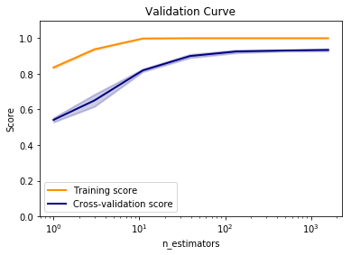

```python
#############################################
# SOLUCION                                  #
#############################################

from sklearn.model_selection import validation_curve

param_range = np.logspace(0, 3.2, 7).astype(np.int)
param_name="n_estimators"
train_scores, test_scores = validation_curve(
     ensemble.RandomForestClassifier(), X_train_pca, y_train,
     param_name=param_name, param_range=param_range,
     cv=5, scoring="accuracy", n_jobs=4)
train_scores_mean = np.mean(train_scores, axis=1)
train_scores_std = np.std(train_scores, axis=1)
test_scores_mean = np.mean(test_scores, axis=1)
test_scores_std = np.std(test_scores, axis=1)

plt.title("Validation Curve")
plt.xlabel(param_name)
plt.ylabel("Score")
plt.ylim(0.0, 1.1)
lw = 2
plt.semilogx(param_range, train_scores_mean, label="Training score",
             color="darkorange", lw=lw)
plt.fill_between(param_range, train_scores_mean - train_scores_std,
                 train_scores_mean + train_scores_std, alpha=0.2,
                 color="darkorange", lw=lw)
plt.semilogx(param_range, test_scores_mean, label="Cross-validation score",
             color="navy", lw=lw)
plt.fill_between(param_range, test_scores_mean - test_scores_std,
                 test_scores_mean + test_scores_std, alpha=0.2,
                 color="navy", lw=lw)
plt.legend(loc="best")
plt.show()
```

**Análisis:** Incrementa indefinidamente la precisión con el número de árboles combinados? Si satura, lo hace a la precisión máxima o a otro valor? Porqué?

**Solución:**  
La precisión no aumenta indefinidamente con el número de árboles combinados, sinó que se satura a un valor alrededor del 93%. Añadir más árboles sólo es útil cuando estos añaden información nueva, porque han sido entrenados con datos distintos que permiten al algoritmo mejorar las decisiones tomadas. La parcialidad de un clasificador, por falta de riqueza en los datos o falta de atributos esenciales, no puede ser totalmente solucionada añadiendo nuevos clasificadores parciales.

### 1.1.6 Volumen de datos (1 punto)

Será que entrenando el modelo con más datos (más imágenes) el modelo aprendería a clasificar con mejor precisión? Es muy útil intentar responder a esta pregunta antes de lanzarse a conseguir más datos, ya que este puede ser un proceso difícil, caro, o que implique esperar mucho tiempo.

Para responder a esta pregunta, analizaremos cómo evoluciona la precisión del modelo en los conjuntos de entrenamiento y test para diferentes volúmenes de datos de creciente tamaño. Representar los resultados en una curva de aprendizaje (*learning curve*) nos permitirá analizar visualmente estas cantidades.

**Implementación:** Entrena varios modelos de *Random Forest* con un volumen de datos cada vez mayor. Para cada modelo, calcula su precisón en el conjunto de entrenamiento y de test, y representa los resutados en un gráfico.

Sugerencia: usar el módulo *learning_curve* de sklearn. Para aprender a usar este módulo os recomendamos los siguientes enlaces:  
http://scikit-learn.org/stable/modules/learning_curve.html#learning-curve  
http://scikit-learn.org/stable/modules/generated/sklearn.model_selection.learning_curve.html

```
<module 'matplotlib.pyplot' from 'C:\\ProgramData\\Anaconda2\\envs\\py36\\lib\\site-packages\\matplotlib\\pyplot.py'>
```

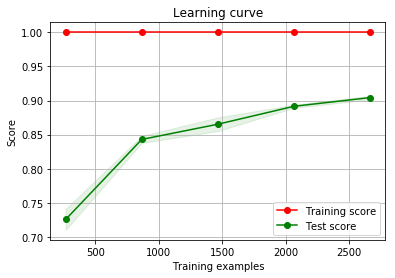

```python
#############################################
# SOLUCION                                  #
#############################################

from sklearn.model_selection import learning_curve

def plot_learning_curve(estimator, title, X, y, ylim=None, cv=None,
                        n_jobs=1, train_sizes=np.linspace(.1, 1.0, 5)):
    """
    Generate a simple plot of the test and training learning curve.

    Parameters
    ----------
    estimator : object type that implements the "fit" and "predict" methods
        An object of that type which is cloned for each validation.

    title : string
        Title for the chart.

    X : array-like, shape (n_samples, n_features)
        Training vector, where n_samples is the number of samples and
        n_features is the number of features.

    y : array-like, shape (n_samples) or (n_samples, n_features), optional
        Target relative to X for classification or regression;
        None for unsupervised learning.

    ylim : tuple, shape (ymin, ymax), optional
        Defines minimum and maximum yvalues plotted.

    cv : int, cross-validation generator or an iterable, optional
        Determines the cross-validation splitting strategy.
        Possible inputs for cv are:
          - None, to use the default 3-fold cross-validation,
          - integer, to specify the number of folds.
          - An object to be used as a cross-validation generator.
          - An iterable yielding train/test splits.

        For integer/None inputs, if ``y`` is binary or multiclass,
        :class:`StratifiedKFold` used. If the estimator is not a classifier
        or if ``y`` is neither binary nor multiclass, :class:`KFold` is used.

        Refer :ref:`User Guide <cross_validation>` for the various
        cross-validators that can be used here.

    n_jobs : integer, optional
        Number of jobs to run in parallel (default 1).
    """
    plt.figure()
    plt.title(title)
    #if ylim is not None:
    #    plt.ylim(*ylim)
    plt.xlabel("Training examples")
    plt.ylabel("Score")
    train_sizes, train_scores, test_scores = learning_curve(
        estimator, X, y, cv=cv, n_jobs=n_jobs, train_sizes=train_sizes)
    train_scores_mean = np.mean(train_scores, axis=1)
    train_scores_std = np.std(train_scores, axis=1)
    test_scores_mean = np.mean(test_scores, axis=1)
    test_scores_std = np.std(test_scores, axis=1)
    plt.grid()

    plt.fill_between(train_sizes, train_scores_mean - train_scores_std,
                     train_scores_mean + train_scores_std, alpha=0.1,
                     color="r")
    plt.fill_between(train_sizes, test_scores_mean - test_scores_std,
                     test_scores_mean + test_scores_std, alpha=0.1, color="g")
    plt.plot(train_sizes, train_scores_mean, 'o-', color="r",
             label="Training score")
    plt.plot(train_sizes, test_scores_mean, 'o-', color="g",
             label="Test score")

    plt.legend(loc="best")
    return plt

plot_learning_curve(ensemble.RandomForestClassifier(n_estimators=50), "Learning curve", X_train_pca, y_train)
```

**Análisis:** Crees que si obtuviésemos más datos de entrenamiento (más imágines clasificadas) mejoraría el modelo? Porqué?

**Solución:**  
En el gráfico vemos que la precisión del modelo en el conjunto de datos de entrenamiento es la máxima posible, por lo que el modelo consigue clasificar perfectamente esas imágenes. Sin embargo, la precisión en el conjunto de test está muy por debajo. Esto nos muestra que el modelo no generaliza suficientemente la lógica de clasificación de las imágenes, sinó que esta lógica es demasiado específica del conjunto usado para entrenar el modelo. Este problema se conoce como *overfitting* y podría ser solucionado añadiendo más datos (más imágenes clasificadas). Por otro lado, en el gráfico también vemos que la precisión en el conjunto de test aumenta al aumentar el volumen de datos (aunque cada vez más lentamente), por lo que esperamos que la precisión continúe aumentando ligeramente si tuviésemos más imágenes.

## 1.2 Boosting (1 punto)

En el sistema de *Boosting* se combinan vários clasificadores débiles sequencialmente, y en cada uno de ellos se da más peso a los datos que han sido erróneamente clasificados en las combinaciones anteriores, para que se concentre así en los casos más difíciles de resolver.

**Implementación:** Usando el conjunto *X_train_pca*, entrena un modelo Gradient Boosting y estima la precisión del modelo con una estrategia de *cross-validation* en los mismos conjuntos. Seguidamente calcula las previsiones del modelo en el conjunto *X_test_pca* y su precisión en este conjunto.

Sugerencia: usar los módulos *GradientBoostingClassifier* y *cross_val_score* de sklearn. Para aprender a usar este módulo os recomendamos el siguientes enlace:  
http://scikit-learn.org/stable/modules/generated/sklearn.ensemble.GradientBoostingClassifier.html

**Solución:**

```python
from sklearn import ensemble
from sklearn.model_selection import cross_val_score

clf = ensemble.GradientBoostingClassifier()

cvscores = cross_val_score(clf, X_train_pca, y_train, cv=5)

print("Precisión media obtenida con CV: {:.2f} +/- {:.2f} %".format(np.mean(cvscores)*100, np.std(cvscores)*100))

clf.fit(X_train_pca, y_train)

preds_gbc = clf.predict(X_test_pca)

# Calcular las probabilidades de cada clase para cada imagen:
probs_gbc = clf.predict_proba(X_test_pca)
```

```
Precisión media obtenida con CV: 91.53 +/- 0.94 %
```

**Análisis:** El boosting se basa en la combinación de clasificadores débiles. En la implementación que utilizaste en este ejercicio, cuál es la profundidad de los árboles utilizados? Compárala con la que utilizaste en los árboles de decisión del ejercicio de *bagging*.

**Solución:**  
Por defecto en la implementación de sklearn se impone un límite de 3 niveles de profundidad en los árboles usados para el *boosting*, mientras que para el *bagging* usamos árboles sin límite de profundidad.

# 2. Combinación secuencial de clasificadores base diferentes

## 2.1 Stacking (1 punto)

Un clasificador de *stacking* usa como atributos las predicciones hechas por otros clasificadores en lugar de los datos originales de entrada.

Para construir nuestro clasificador de *stacking* vamos a usar las predicciones hechas en el conjunto de test por los clasificadores utilizados en los ejercicios anteriores de esta PEC, así como de otros clasificadores. Os proporcionamos las predicciones hechas sobre el mismo conjunto de test por clasificadores K-Nearest neighbors Classifier (knc), Support Vector Machines Classifier (svmc) y Neural Network Classifier (nnc) en archivos adjuntos. Estas predicciones se pueden cargar con el siguiente código:

```python
# carga de predicciones calculadas con otros clasificadores:
preds_knc = np.load("preds_knc.pickle")
preds_svmc = np.load("preds_svmc.pickle")
preds_nnc = np.load("preds_nnc.pickle")
```

**Implementación:** Construye un clasificador de *stacking* usando una *Random Forest* que use como atributos a las predicciones hechas en el conjunto de test por los algoritmos k-nn, SVM, red neuronal y Gradient Boosting. Calcula la precisión del modelo resultante con *cross-validation* en el conjunto de test.

Sugerencia: usar las funciones column_stack de numpy y OneHotEncoder de sklearn para preparar los datos. Para aprender a usar estas funciones os recomendamos los siguientes enlaces:  
https://docs.scipy.org/doc/numpy-1.14.0/reference/generated/numpy.column_stack.html  
http://scikit-learn.org/stable/modules/generated/sklearn.preprocessing.OneHotEncoder.html  
http://scikit-learn.org/stable/modules/preprocessing.html#encoding-categorical-features

**Solución:**

```python
#############################################
# SOLUCION                                  #
#############################################

# Juntar las predicciones de los distintos clasificadores:
X_test_stacking = np.column_stack((preds_rfc, preds_gbc, preds_knc, preds_svmc, preds_nnc))
print("Dimensiones de la matriz con las predicciones de todos los clasificadores: {}".format(np.shape(X_test_stacking)))

# Transformar las variables categóricas (son todas) con OneHotEncoder:
from sklearn.preprocessing import OneHotEncoder
enc = OneHotEncoder()
enc.fit(X_test_stacking)
X_test_stacking = enc.transform(X_test_stacking).toarray()
print("Dimensiones de la matriz para entrenar el clasificador de stacking: {}".format(np.shape(X_test_stacking)))

# Calcular la precisión de un RandomForestClassifier con estas variables usando CV:
clf = ensemble.RandomForestClassifier(n_estimators=100)
cvscores = cross_val_score(clf, X_test_stacking, y_test, cv=5)
print("Precisión media obtenida con CV: {:.2f} +/- {:.2f} %".format(np.mean(cvscores)*100, np.std(cvscores)*100))
```

```
Dimensiones de la matriz con las predicciones de todos los clasificadores: (1000, 5)
Dimensiones de la matriz para entrenar el clasificador de stacking: (1000, 25)
Precisión media obtenida con CV: 96.80 +/- 1.36 %
```

**Análisis:** Has conseguido mejorar la precisión gracias al *stacking*? Comenta el resultado.

**Solución:**  
La precisión obtenida gracias al *stacking* es claramente superior a la obtenida con los modelos de Random Forest y Gradient Boosting usados en esta práctica. Sin embargo en los resultados de la práctica anterior habíamos obtenido una precisión cercana al 96%, por lo que la mejora global es muy pequena. Aunque las desviaciones de las precisiones medias con CV son del mismo orden que la mejora obtenida, repitiendo el cálculo para diferentes *seeds* nos dá resultados consistentes en los que el *stacking* es siempre ligeramente superior.

## 2.2 Cascading

### 2.2.1 Cascading simple

El caso de *cascading* es parecido al de *stacking* pero utilizando no solamente las predicciones parciales de los clasificadores base, sino también los datos originales.

**Implementación:** Construye un clasificador de *cascading* usando una *Random Forest* que use como atributos a las predicciones hechas en el conjunto de test por los algoritmos k-nn, SVM, red neuronal y Gradient Boosting, así como también las variables originales. Calcula la precisión del modelo resultante con *cross-validation* en el conjunto de test.

Sugerencia: Usa el mismo conjunto de datos que en el ejercicio anterior pero añade el conjunto de test original *X_test_pca*.

**Solución:**

```python
#############################################
# SOLUCION                                  #
#############################################

# Juntar las predicciones de los distintos clasificadores y las variables originales:
X_test_cascading = np.column_stack((X_test_pca, X_test_stacking))
print("Dimensiones de la matriz: {}".format(np.shape(X_test_cascading)))

# Calcular la precisión de un RandomForestClassifier con estas variables usando CV:
clf = ensemble.RandomForestClassifier(n_estimators=100)
cvscores = cross_val_score(clf, X_test_cascading, y_test, cv=5)
print("Precisión media obtenida con CV: {:.2f} +/- {:.2f} %".format(np.mean(cvscores)*100, np.std(cvscores)*100))
```

```
Dimensiones de la matriz: (1000, 125)
Precisión media obtenida con CV: 96.70 +/- 1.47 %
```

**Análisis:** Has conseguido mejorar la precisión gracias al *cascading*? Comenta el resultado.

### 2.2.2 Cascading con variables adicionales (1 punto)

En el *cascading* también podemos añadir como variables del modelo a datos adicionales que se hayan podido generar durante la toma de decisiones de los clasificadores que combinamos.

**Implementación:** Qué datos adicionales de los modelos anteriores podrías usar para enriquecer al modelo? Construye un clasificador de *cascading* usando una *Random Forest* que use como atributos a los usados en el ejercicio anterior más otros que puedas obtener de algunos de los clasificadores utilizados en los ejercicios anteriores. Calcula la precisión del modelo resultante con *cross-validation* en el conjunto de test.

**Solución:**

```python
#############################################
# SOLUCION                                  #
#############################################

# Carga datos:
probs_knc = np.load("probs_knc.pickle")
probs_svmc = np.load("probs_svmc.pickle")

# Juntar las predicciones de los distintos clasificadores incluyendo las probabilidades en cada clase:
X_test_cascading = np.column_stack((X_test_pca, probs_rfc, probs_gbc, probs_knc, probs_svmc, X_test_stacking))
print("Dimensiones de la matriz: {}".format(np.shape(X_test_cascading)))

# Calcular la precisión de un RandomForestClassifier con estas variables usando CV:
clf = ensemble.RandomForestClassifier(n_estimators=100)
cvscores = cross_val_score(clf, X_test_cascading, y_test, cv=5)
print("Precisión media obtenida con CV: {:.2f} +/- {:.2f} %".format(np.mean(cvscores)*100, np.std(cvscores)*100))
```

```
Dimensiones de la matriz: (1000, 145)
Precisión media obtenida con CV: 96.60 +/- 1.39 %
```

**Análisis:** Has conseguido mejorar la precisión gracias a añadir datos adicionales al *stacking*? Comenta el resultado.